# Using the Boruta Package to Determine Feature Relevance

2020-06-22 11:10:41

The code below is based on the information found at https://www.kaggle.com/jimthompson/using-the-boruta-package-to-determine-fe.

This report determines what features may be relevant to modeling the **target** attribute for the case_8 data set. This analysis is based on the [**Boruta**](https://cran.r-project.org/web/packages/Boruta/index.html) package. In addition we demonstrate the [**caret**](https://cran.r-project.org/web/packages/caret/index.html) package functions to create data partitions and impute missing values.

First, we load required libraries.

```r
# required libraries
library(caret)
library(Boruta)
library(dplyr)
```

Read in the case_8 data set, determine data types and perform simple pre-processing for numeric data.

```r
# retrive sample data for analysis
train <- read.csv(("data/case_8.csv"),stringsAsFactors = FALSE)

###
# select random sample for analysis using caret createDataPartition() function
###
set.seed(123)
idx <- createDataPartition(train$target,p=0.05,list=FALSE)
sample.df <- train[idx,]

###
# segregate numeric vs character data types
###
# get names of the explanatory variables
explanatory.attributes <- setdiff(names(sample.df),c("ID","target"))

# determine data type for each explanatory variable
data.classes <- sapply(explanatory.attributes,function(x){class(sample.df[,x])})

# segregate explanatory variables by data type, eg. character, numeric, integer
unique.classes <- unique(data.classes)
attr.by.data.types <- lapply(unique.classes,function(x){names(data.classes[data.classes==x])})
names(attr.by.data.types) <- unique.classes
comment(attr.by.data.types) <- "list that categorize training data types"


# for numeric attributes use caret preProcess() and predict() functions to impute missing values
pp <- preProcess(sample.df[c(attr.by.data.types$numeric,attr.by.data.types$integer)],
                 method=c("medianImpute"))
pp.sample.df <- predict(pp,sample.df[c(attr.by.data.types$numeric,attr.by.data.types$integer)])

# combine numeric data with character data
df <- cbind(pp.sample.df,sample.df[attr.by.data.types$character])
```

Analyze sample data with Boruta package to determine relevance of the explanatory variables.

```r
set.seed(13)
bor.results <- Boruta(df,factor(sample.df$target),
                   maxRuns=101,
                   doTrace=0)
```

```
##
## summary of Boruta run:
```

```
## Boruta performed 100 iterations in 1.159391 hours.
##  67 attributes confirmed important: v10, v100, v101, v105, v106 and 62
## more;
##  37 attributes confirmed unimportant: v1, v103, v107, v11, v112 and 32
## more;
##  27 tentative attributes left: v102, v104, v111, v116, v117 and 22
## more;
```

```
##
##
## Attributes determined to be relevant:
```

```
##  [1] "v2"   "v4"   "v7"   "v8"   "v10"  "v12"  "v14"  "v17"  "v21"  "v23"
## [11] "v25"  "v26"  "v27"  "v29"  "v33"  "v34"  "v36"  "v40"  "v41"  "v44"
## [21] "v45"  "v46"  "v48"  "v50"  "v51"  "v54"  "v55"  "v58"  "v60"  "v61"
## [31] "v63"  "v64"  "v65"  "v70"  "v76"  "v81"  "v83"  "v85"  "v87"  "v88"
## [41] "v89"  "v93"  "v95"  "v96"  "v98"  "v100" "v101" "v105" "v106" "v108"
## [51] "v109" "v114" "v119" "v121" "v123" "v128" "v130" "v62"  "v129" "v24"
## [61] "v31"  "v47"  "v56"  "v66"  "v79"  "v110" "v113"
```

The following plot shows the relevance of each feature. Green color indicate the feature has been deemed relevance to the **target** attribute. Red color indicates the attribute is not relevant. Yellow attributes are tentative, may or may not be relevant. Increasing maxRuns parameter can help further refine the list of tentative attributes as relevant or not.

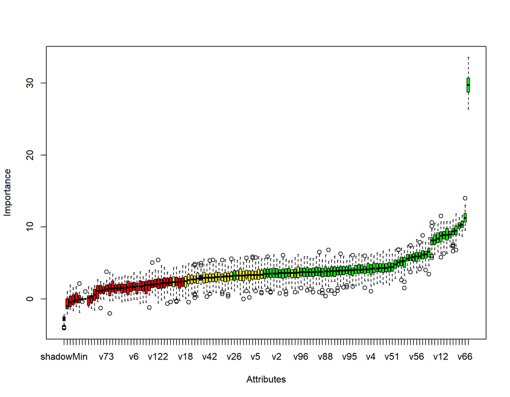

Detailed results for each explanatory results.

```
##
##
## Attribute importance details:
```

```
##     attr     meanImp   medianImp       minImp    maxImp normHits  decision
## 1    v50 29.79088517 29.72756803 26.411611600 33.592322     1.00 Confirmed
## 2    v66 11.29303754 11.24816912  9.525859102 13.973102     1.00 Confirmed
## 3   v110 10.30711388 10.29302017  8.702241179 11.618169     1.00 Confirmed
## 4    v47 10.15812615 10.21442172  8.815571436 11.271183     1.00 Confirmed
## 5    v14  9.54033626  9.45714576  6.806480973 11.830415     1.00 Confirmed
## 6   v114  9.30277494  9.39428022  6.640176290 11.004941     1.00 Confirmed
## 7    v10  8.96915812  8.94738294  7.235541394 10.758906     1.00 Confirmed
## 8   v113  8.89352794  8.90946336  6.331213021 10.769039     1.00 Confirmed
## 9    v31  8.81279350  8.87952092  6.308623869 10.702047     1.00 Confirmed
## 10   v12  8.69769937  8.78436123  5.770087571 11.509317     1.00 Confirmed
## 11   v40  8.42781940  8.36403186  6.510927323 10.426081     1.00 Confirmed
## 12   v21  8.21316073  8.16191124  6.130127046 10.540322     1.00 Confirmed
## 13   v34  8.01320082  8.10938068  5.692837963 10.613254     1.00 Confirmed
## 14   v62  6.44304323  6.55505624  3.448632788  8.532194     1.00 Confirmed
```

[output cut: 117 more lines]